# Design

This was a pilot experiment in which we aimed to find the most appropriate memory test to be used after a training in which two cues are presented in each trial followed by an outcome. Only one of the cues is predictive of the outcome, whereas the other appears the same amount of times with each of the two possible outcomes. Two tests where used, one followed by the other in all cases. Test 1 consisted in presenting one of the cues saw in the training phase and a dis tractor cue that was similar to this cue. The similarity of the distractor was manipulated between-subjects, with 3 possible conditions: very subtle (only one pair of balls swapped colors), subtle (two pairs of balls swapped colors) and no subtle (the distractor is a palette-swap of the target). In test 2, the target is presented with the distractors similar to the rest of the targets, one per trial.

| Training | Test1 | Test2 |
| --- | --- | --- |
| AX - O1 | A vs *a* | A vs *b* A vs *x* A vs *y* |
| AY - O1 | B vs *b* | B vs *a* B vs *x* B vs *y* |
| BX - 02 | X vs *x* | X vs *a* X vs *b* X vs *y* |
| BY - O2 | Y vs *y* | Y vs *a* Y vs *b* Y vs *x* |

# All Data

## Training phase

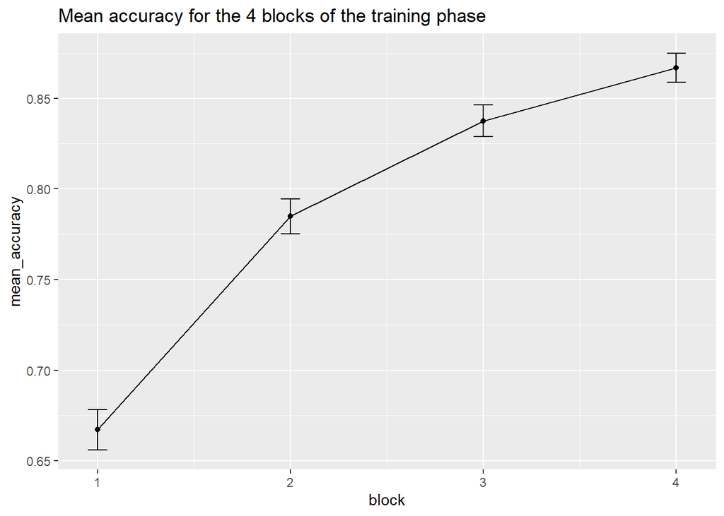

## Test1

### Accuracy

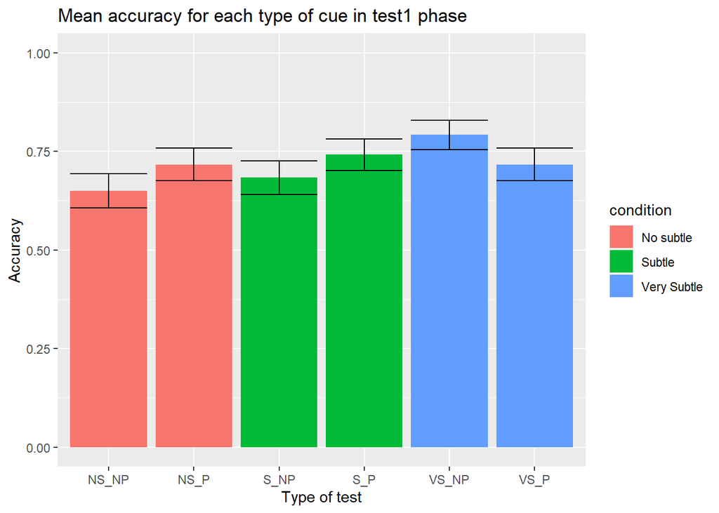

Except for those that did the very subtle test, all subjects had lower accuracy for the non predictive vs the predictive targets. However, there were no significant differences due to the type of test (*F*(2, 87) = 0.87, *p* = .425, $\eta^2_p$ = .02), the predictiveness of the target (*F*(1, 87) = 0.23, *p* = .635, $\eta^2_p$ < .01) nor the interaction between them (*F*(2, 87) = 1.72, *p* = .185, $\eta^2_p$ = .04). In all cases, bayesian evidence for the null hypotesis was either anecdotal or moderate (BF<sub>10</sub> = 1.7x10<sup>-1</sup> ± 1.62%, BF<sub>10</sub> = 1.8x10<sup>-1</sup> ± 3%, BF<sub>10</sub> = 4.1x10<sup>-1</sup> ± 3.91%, respectively).

### Memory score

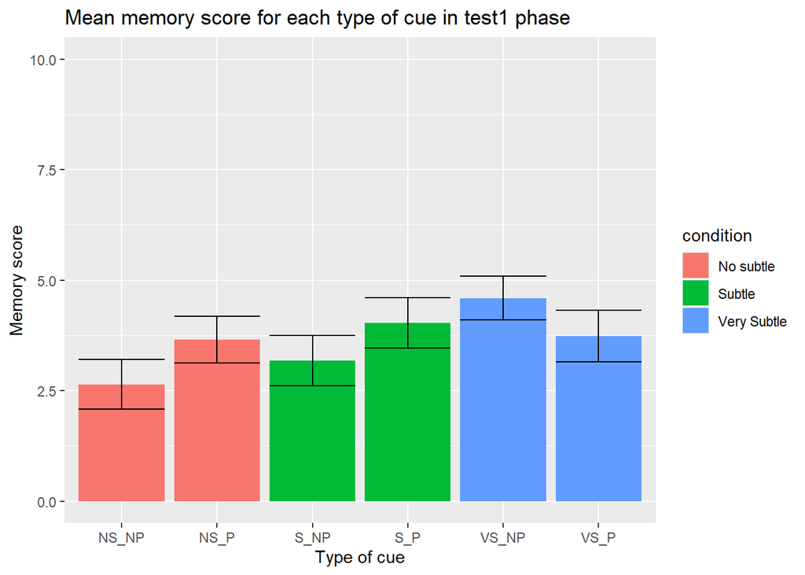

```r
#plot test mem_score
m_mem_test1 <- test1 %>%
  group_by(cue_type, condition) %>%
  summarise(mean_mem_score = mean(mem_score, na.rm = TRUE),
            sd_mem_score = sd(mem_score, na.rm = TRUE)/sqrt(length(mem_score)))
```

Again, except for those that did the very subtle test, all subjects had lower accuracy for the non predictive vs the precitive targets. However, there are no significant differences (Type of test: *F*(2, 87) = 0.75, *p* = .477, $\eta^2_p$ = .02, Predictiveness: *F*(1, 87) = 0.44, *p* = .510, $\eta^2_p$ < .01, interaction; *F*(2, 87) = 1.41, *p* = .251, $\eta^2_p$ = .03) and the bayesian evidence is mild (BF<sub>10</sub> = 1.7x10<sup>-1</sup> ± 0.73%, BF<sub>10</sub> = 2x10<sup>-1</sup> ± 1.08%, BF<sub>10</sub> = 3.1x10<sup>-1</sup> ± 2.59%, respectively).

###Corrected memory score (hits x1, errors x0)

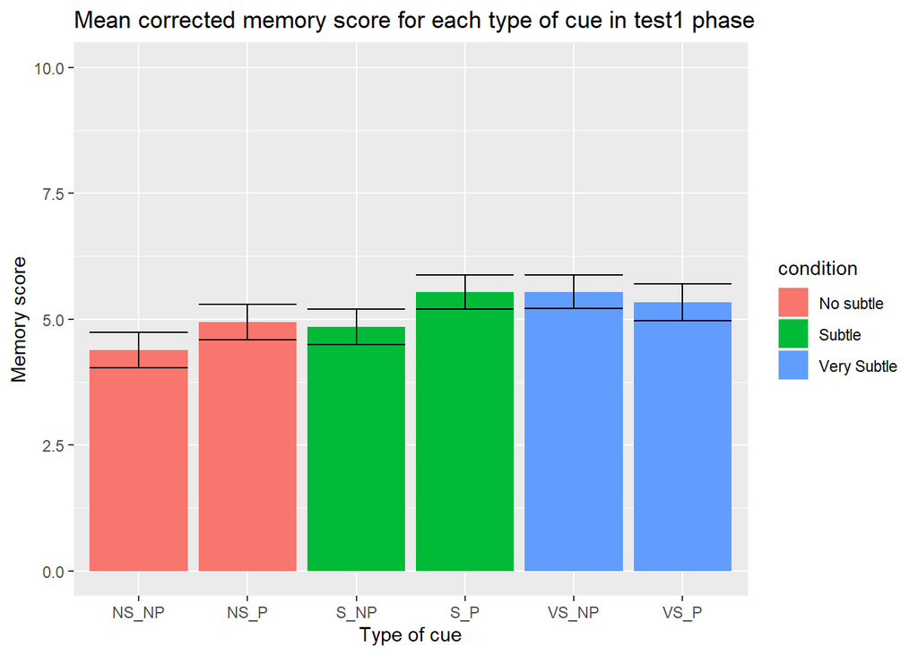

No significant effects where found, and the bayesian evidence was moderate in favoru of the null hypothesis in all cases (Certainty: *F*(2, 87) = 0.88, *p* = .417, $\eta^2_p$ = .02, BF<sub>10</sub> = 2.3x10<sup>-1</sup> ± 0.52%; Predcitiveness: *F*(1, 87) = 1.31, *p* = .255, $\eta^2_p$ = .01, BF<sub>10</sub> = 2.9x10<sup>-1</sup> ± 1.03%; interaction: *F*(2, 87) = 0.87, *p* = .422, $\eta^2_p$ = .02, BF<sub>10</sub> = 1.9x10<sup>-1</sup> ± 2.28%)

### Corrected memory score (errors out)

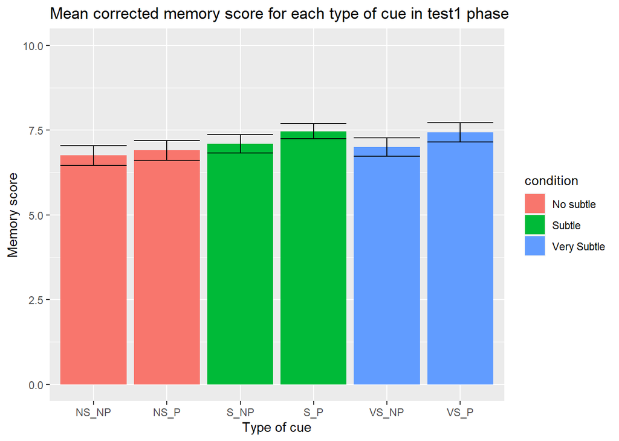

When only hits are taken into account in test 1, there is a significant effect of predictiveness (*F*(1, 82) = 4.70, *p* = .033, $\eta^2_p$ = .05), but the bayesian evidence is anecdotal (BF<sub>10</sub> = 1.2x10<sup>0</sup> ± 1.12%. However, there were no significant effects of the type of test (*F*(2, 82) = 0.86, *p* = .428, $\eta^2_p$ = .02, BF<sub>10</sub> = 2.5x10<sup>-1</sup> ± 0.47%) nor the interaction (*F*(2, 82) = 0.43, *p* = .653, $\eta^2_p$ = .01, BF<sub>10</sub> = 1.2x10<sup>-1</sup> ± 2.43%).

## Test2

### Accuracy

#plot test accuracy

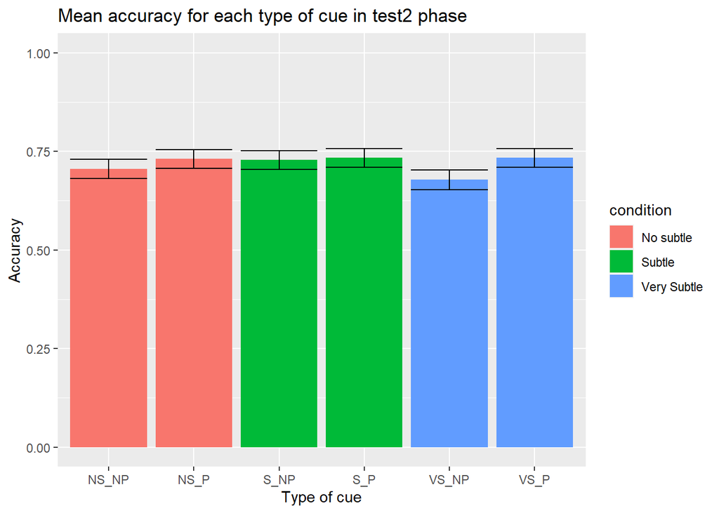

There are no differences in accuracy in the second test, confirmed by the ANOVA (Type of test: *F*(2, 87) = 0.13, *p* = .875, $\eta^2_p$ < .01, Predictiveness: *F*(1, 87) = 1.27, *p* = .262, $\eta^2_p$ = .01, interaction; *F*(2, 87) = 0.33, *p* = .722, $\eta^2_p$ < .01) and the bayesian evidence is anecdotal null (BF<sub>10</sub> = 1.3x10<sup>-1</sup> ± 0.56%, BF<sub>10</sub> = 3x10<sup>-1</sup> ± 3.24%, BF<sub>10</sub> = 1.3x10<sup>-1</sup> ± 2.41%, respectively).

### Memory Score

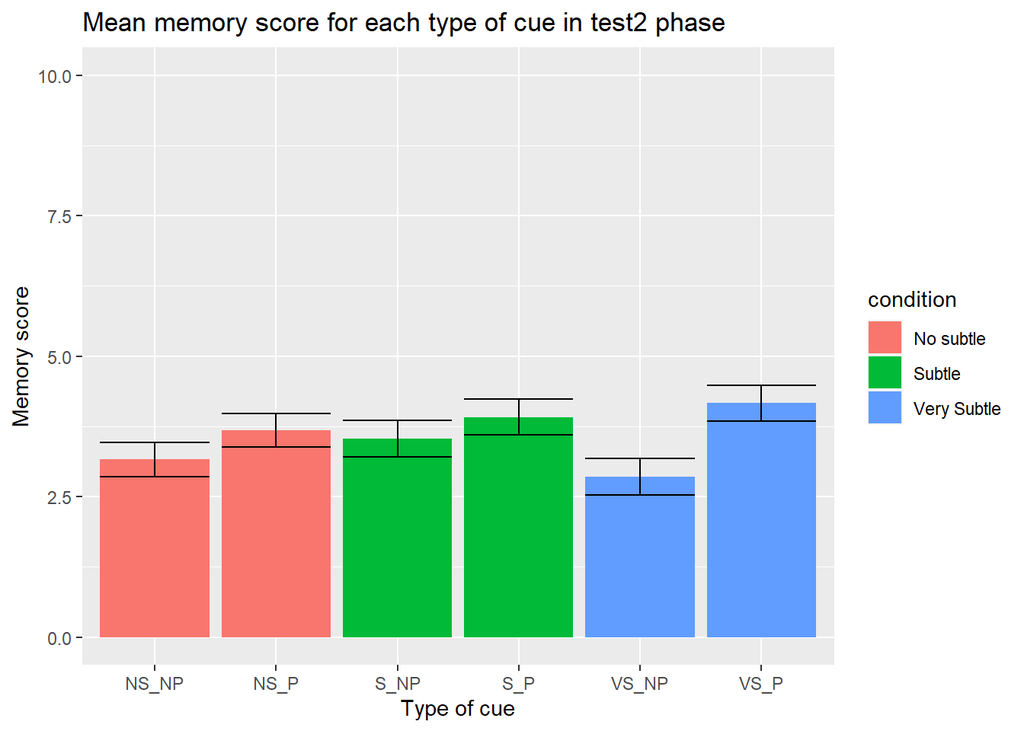

###Corrected memory score (hits x1, errors x0)

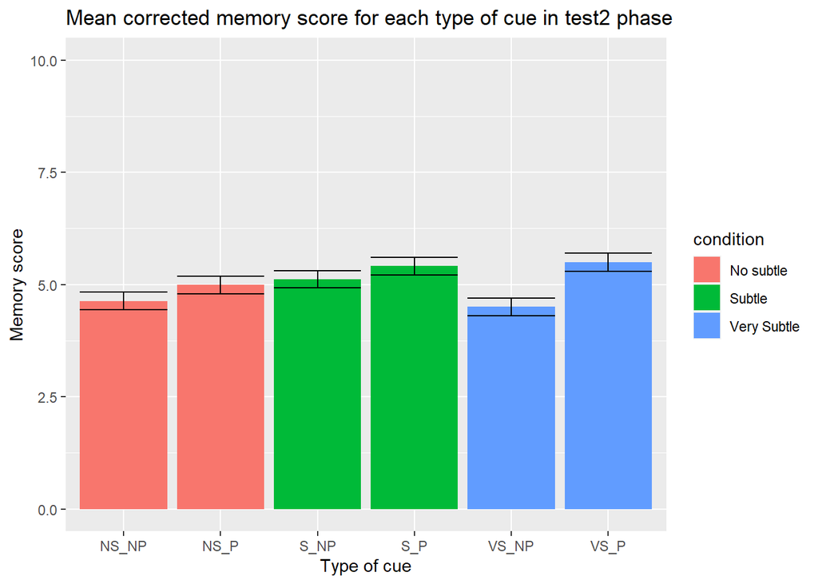

The analyses indicate that there is a significant effect of predictiveness, although bayesian evidence is anecdotal in favor of the alternative hypothesis (*F*(1, 87) = 6.10, *p* = .016, $\eta^2_p$ = .07, BF<sub>10</sub> = 2.5x10<sup>0</sup> ± 0.94%). However, there was not a significant effect of the Similarity nor the interaction, both with moderate bayesian evidence in favor of the null hypothesis (*F*(2, 87) = 0.29, *p* = .751, $\eta^2_p$ < .01, BF<sub>10</sub> = 2.2x10<sup>-1</sup> ± 2.7%; *F*(2, 87) = 0.99, *p* = .374, $\eta^2_p$ = .02, BF<sub>10</sub> = 2.1x10<sup>-1</sup> ± 5.68%; respectively).

### Corrected memory score (errors out)

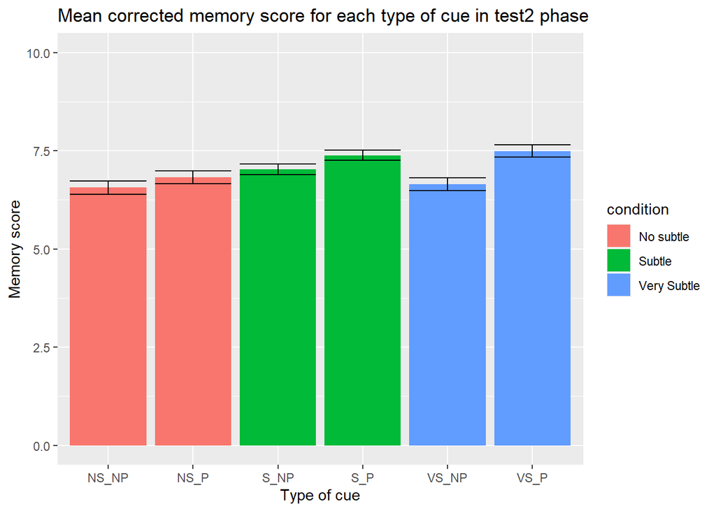

In this case, there´s a clear effect of predictiveness, being the corrected memory score always lower in the non-predicitve targets (*F*(1, 87) = 15.32, *p* < .001, $\eta^2_p$ = .15, BF<sub>10</sub> = 1.1x10<sup>2</sup> ± 3.47%). Again, nor the session nor the interaction were significant (*F*(2, 87) = 0.56, *p* = .572, $\eta^2_p$ = .01, BF<sub>10</sub> = 3.3x10<sup>-1</sup> ± 3.04%; *F*(2, 87) = 2.00, *p* = .141, $\eta^2_p$ = .04, BF<sub>10</sub> = 4.5x10<sup>-1</sup> ± 5.95%).

# Very subtle test

## Test1

### Accuracy

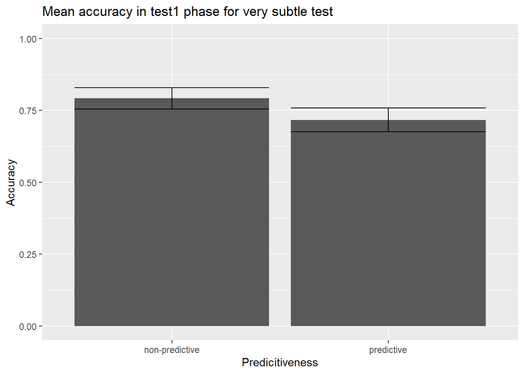

Accuracy is higher in the non-predicitve, but is not significant (*t*(29) = 1.12, *p* = .271, *d* = 0.20) and the bayesian evidence is not conclusive (BF<sub>10</sub> = 3.4x10<sup>-1</sup> ± 0.03%).

### Memory score

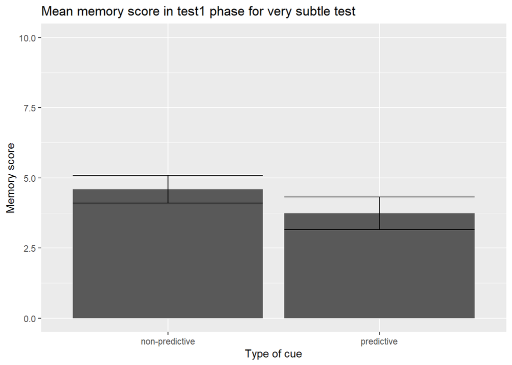

Memory score is higher in the non-predicitve, but is not significant(*t*(29) = 0.89, *p* = .381, *d* = 0.16) and the bayesian evidence is not conclusive (BF<sub>10</sub> = 2.8x10<sup>-1</sup> ± 0.03%).

###Corrected memory score (hits x1, errors x0)

There are no significant differences in test 1 very subtle when the memory score is corrected.

### Corrected memory score (errors out)

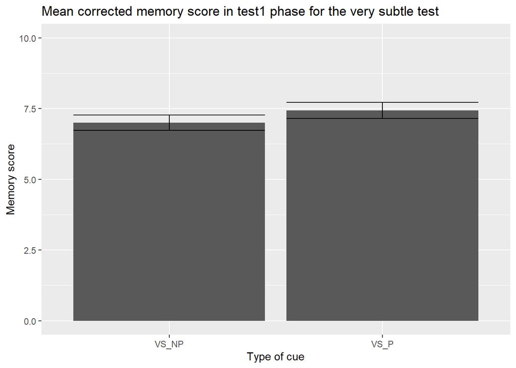

There are no significant differences in test 1 very subtle when the memory score is corrected (*t*(27) = -1.57, *p* = .127, *d* = -0.30, BF<sub>10</sub> = 6x10<sup>-1</sup> ± 0.03%.

## Test2

### Accuracy

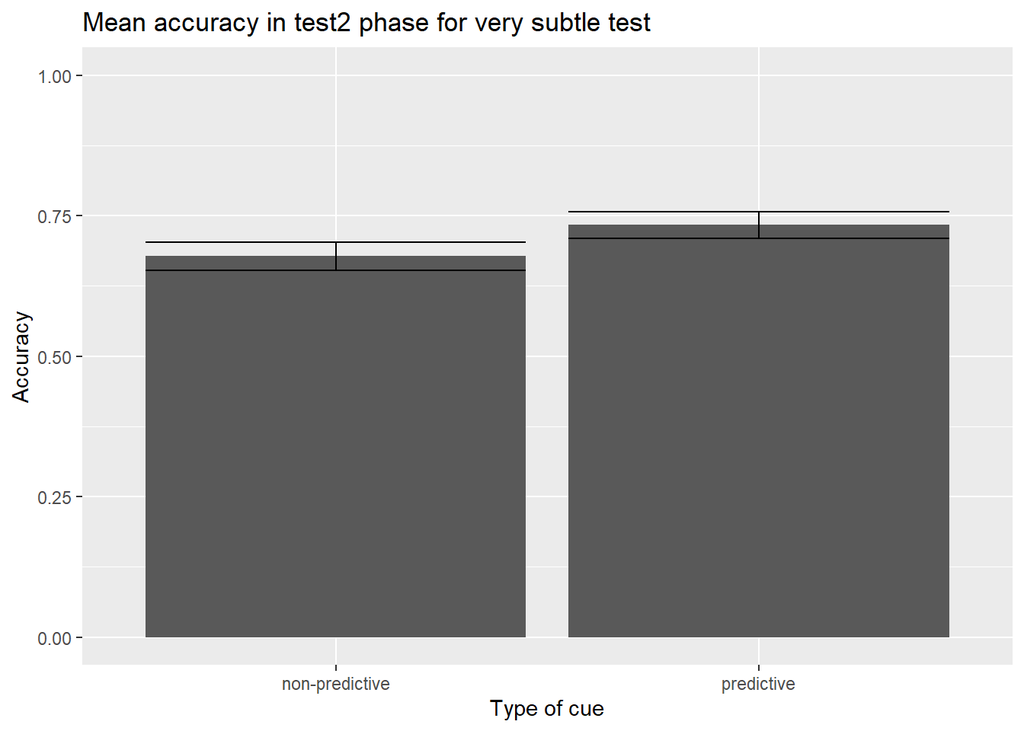

In this case, accuracy is lower for the non-predictive targets, but the difference is not significant and the bayesian evidence is very mild (*t*(29) = -1.44, *p* = .161, *d* = -0.26, BF<sub>10</sub> = 4.9x10<sup>-1</sup> ± 0.03%).

### Memory score

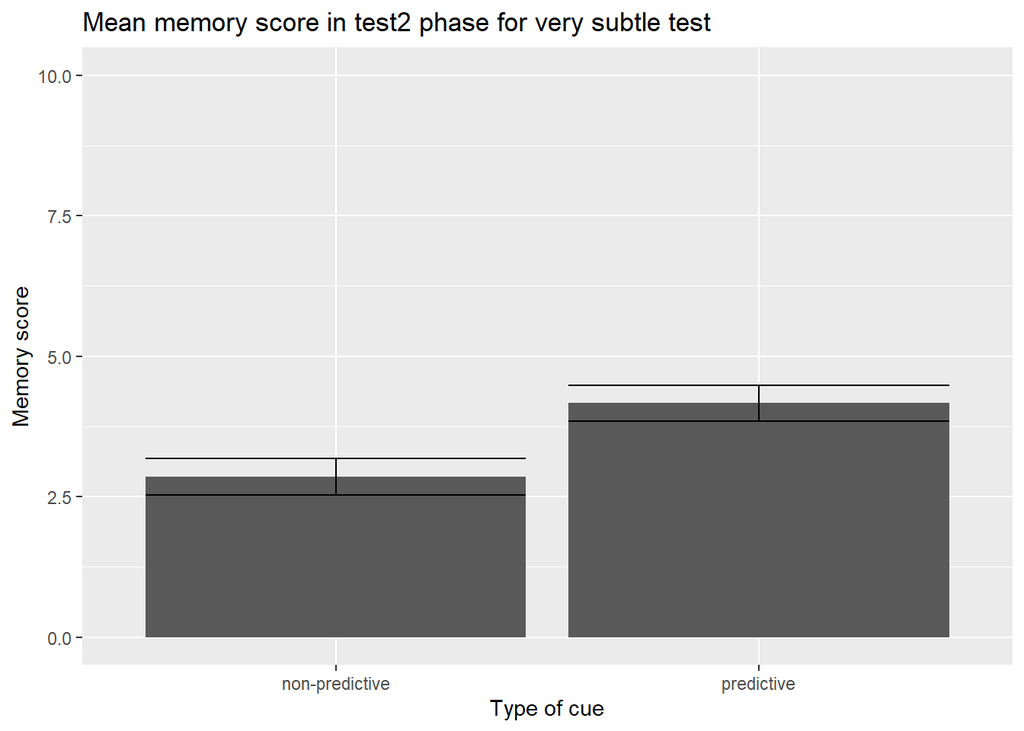

Again, memory score is lower in the non-predicitive group. In this case, there are significant differences (*t*(29) = -2.21, *p* = .035, *d* = -0.40) and anecdotal positive bayesian evidence (BF<sub>10</sub> = 1.6x10<sup>0</sup> ± 0.02%).

###Corrected memory score (hits x1, errors x0)

In this case, there´s a effect of predictiveness with moderate bayesian evidence, being the corrected memory score lower in the non-predicitve targets.

### Corrected memory score (errors out)

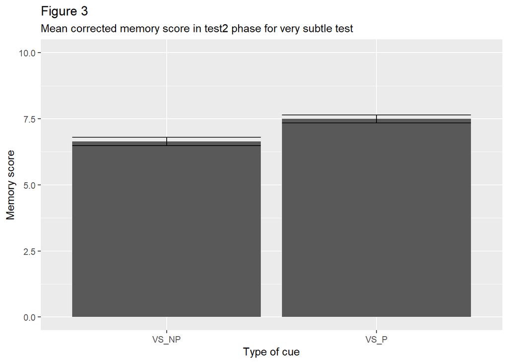

# Subtle test

## Test1

### Accuracy

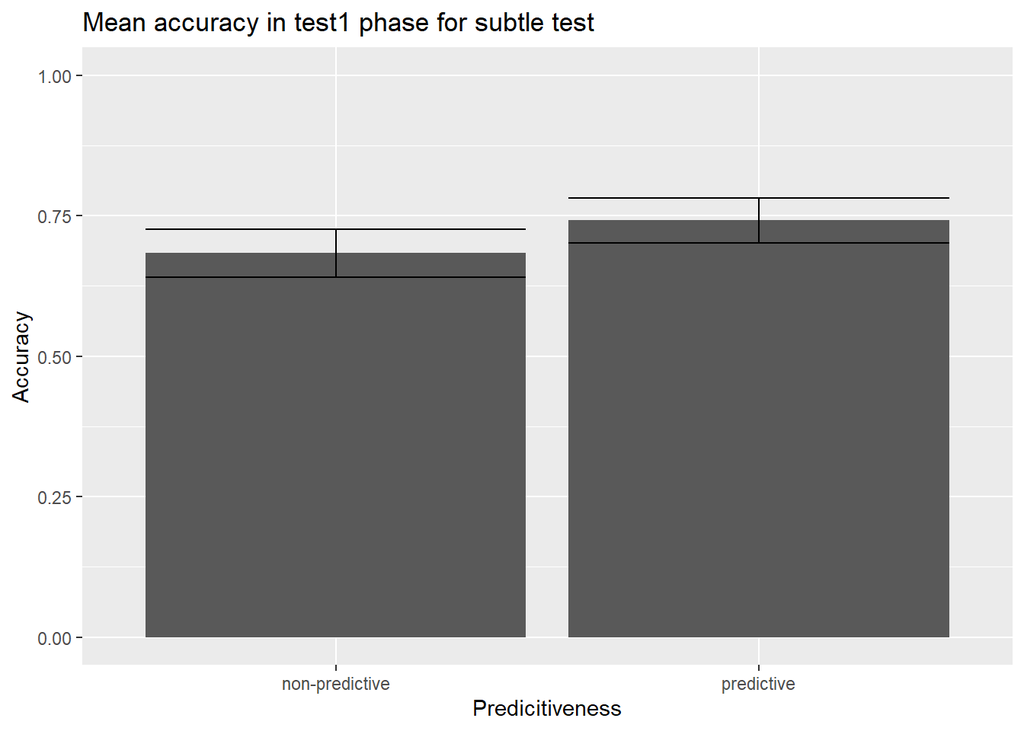

There´s lower accuracy for the non-predictive, but there is no significant difference (*V* =49.5, *p* = 0.3403388, BF<sub>10</sub> = 3.1x10<sup>-1</sup> ± 0.03%).

### Memory score

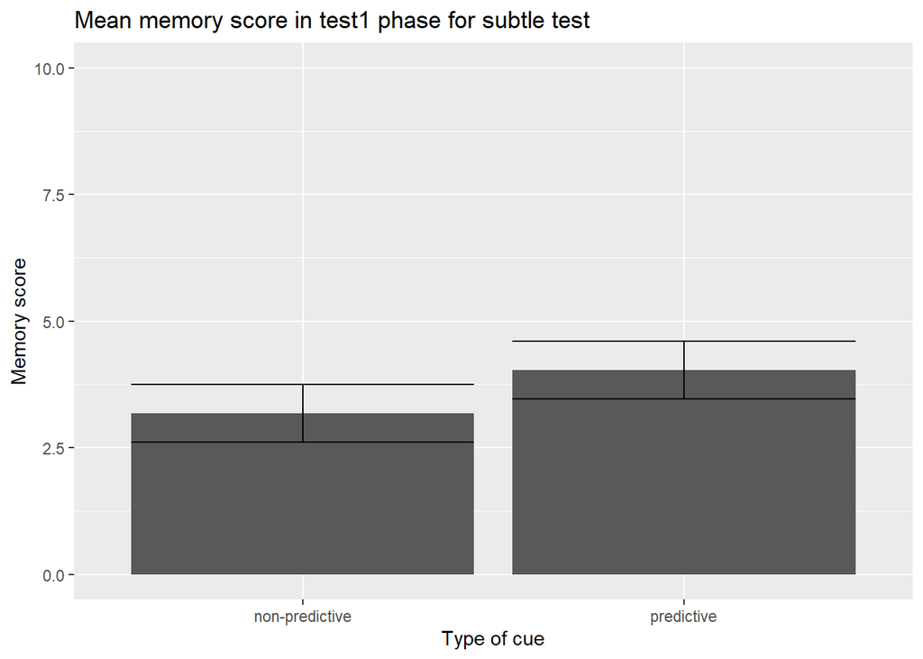

There´s lower memory score for the non-predictive, but there is no significant difference (*t*(29) = -0.96, *p* = .347, *d* = -0.17, BF<sub>10</sub> = 3x10<sup>-1</sup> ± 0.03%).

###Corrected memory score (hits x1, errors x0)

Responding is lower for the non-predictive targets, there are no significant differences and the bayesian test indicates anecdotal evidence for the null hypothesis

### Corrected memory score (errors out)

[figure not shown]

Responding is lower for the non-predictive targets, there are nearly significant differences but the bayesian test indicates anecdotal evidence for the alternative hypothesis (*t*(28) = -1.98, *p* = .057, *d* = -0.37, BF<sub>10</sub> = 1.1x10<sup>0</sup> ± 0.02%).

## Test2

### Accuracy

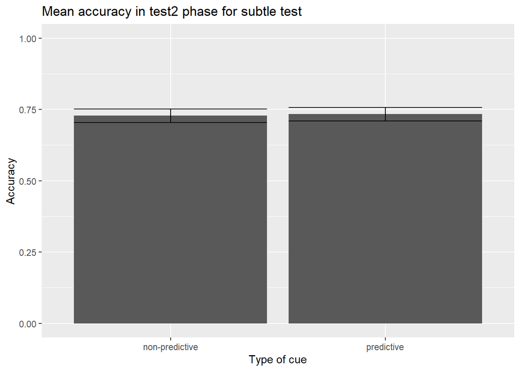

There is no significant difference (*t*(29) = -0.12, *p* = .905, *d* = -0.02, BF<sub>10</sub> = 2x10<sup>-1</sup> ± 0.03%).

### Memory score

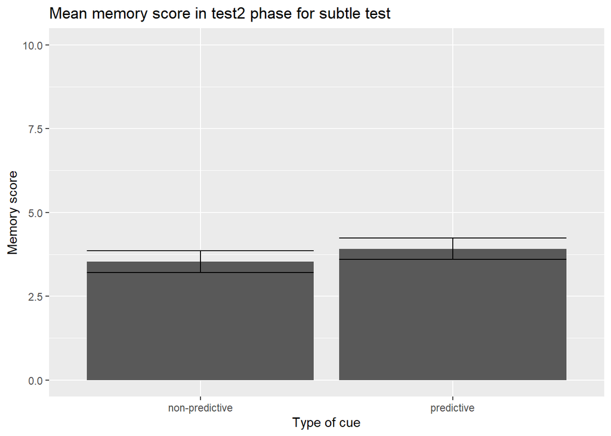

There is no significant difference (*V* = 218, *p* = 1, BF<sub>10</sub> = 2.3x10<sup>-1</sup> ± 0.03%).

###Corrected memory score (hits x1, errors x0)

There is no significant difference.

### Corrected memory score (errors out)

[figure not shown]

There´s lower memory score for the non-predictive, but there is no significant difference (*t*(29) = -1.40, *p* = .171, *d* = -0.26, BF<sub>10</sub> = 4.7x10<sup>-1</sup> ± 0.03%).

# No subtle test

## Test1

### Accuracy

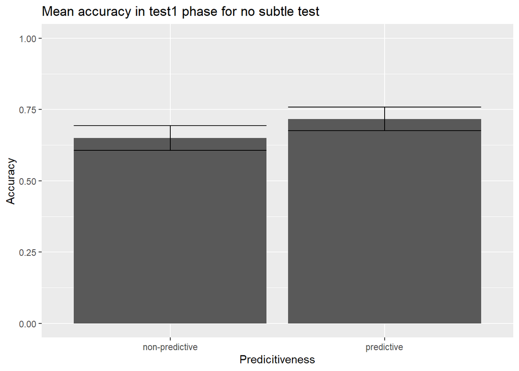

There is no significant difference (*V*= 58.5, *p* = 0.2307725, BF<sub>10</sub> = 3.6x10<sup>-1</sup> ± 0.03%).

### Memory score

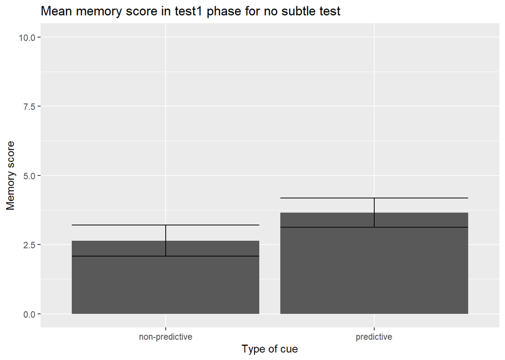

There is no significant difference (*V* = 177, *p* = 0.3869534, BF<sub>10</sub> = 4.4x10<sup>-1</sup> ± 0.03%).

###Corrected memory score (hits x1, errors x0)

There are no significant differences in responding.

### Corrected memory score (errors out)

[figure not shown]

```r
#plot test mem_score but take out the errors
c_test1_s3 <- filter(test1_s3, acc == 1)
c_m_mem_test1_s3 <- c_test1_s3 %>%
  group_by(cue_type) %>%
  summarise(mean_mem_score = mean(mem_score, na.rm = TRUE),
            sd_mem_score = sd(mem_score, na.rm = TRUE)/sqrt(length(mem_score)))
```

There are no significant differences in responding (*t*(27) = -0.44, *p* = .663, *d* = -0.08, BF<sub>10</sub> = 2.2x10<sup>-1</sup> ± 0.03%).

## Test2

### Accuracy

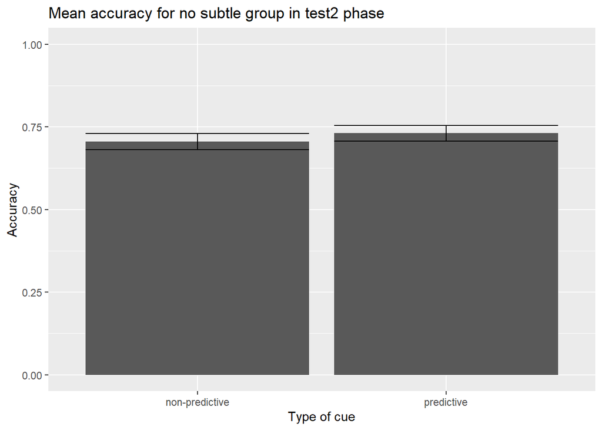

There are no differences in responding depending on the predictiveness of the target (*t*(29) = -0.53, *p* = .597, *d* = -0.10, BF<sub>10</sub> = 2.2x10<sup>-1</sup> ± 0.03%).

### Memory score

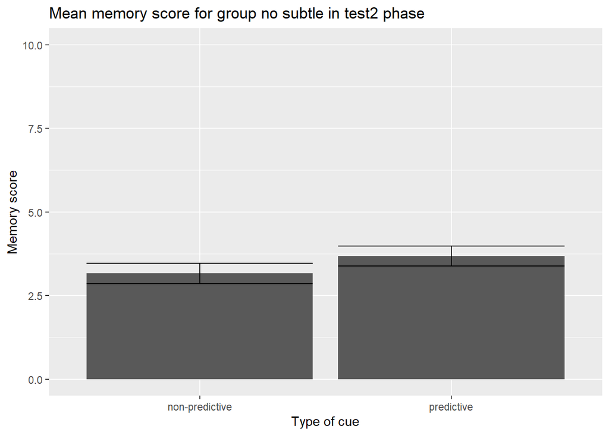

There´s lower memory score for the non-predictive, but there is no significant difference (*t*(29) = -0.83, *p* = .415, *d* = -0.15, BF<sub>10</sub> = 2.7x10<sup>-1</sup> ± 0.03%).

###Corrected memory score (hits x1, errors x0)

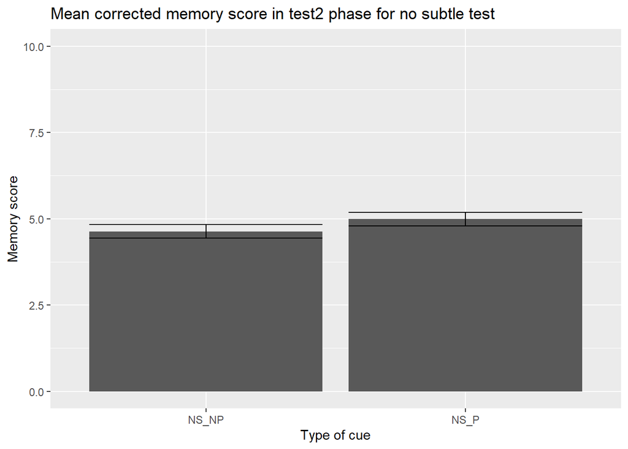

There is no significant difference.

### Corrected memory score (errors out)

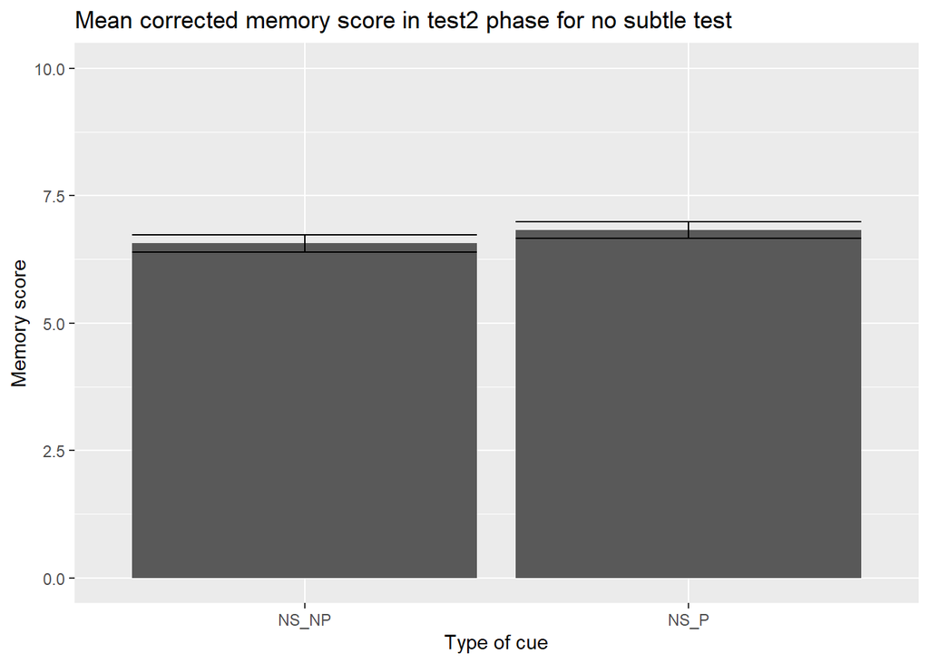

There´s lower memory score for the non-predictive, but there is no significant difference (*t*(29) = -1.39, *p* = .176, *d* = -0.25, BF<sub>10</sub> = 4.6x10<sup>-1</sup> ± 0.03%).